# PROSPER: Exploring a Loan Company's Data to Evaluate Performance and Uncover Business Opportunities

## By: Ayobami Yusuf

## Overview

> Prosper Marketplace was founded in 2005 as the first peer-to-peer lending marketplace in the United States. Since then, Prosper has facilitated more than 21 billion USD in loans to over 1.3 million people. Borrowers apply online for a fixed-rate, fixed-term loan between 2000 USD and 40000 USD.

> **How has Prosper performed over the years? And are there any trends and relationships in its data that may be useful in understanding specific characteristics of Prosper's loan listings?**

## Dataset Overview

> The dataset analyzed is obtained from Prosper. The original dataset contains 81 variables, but focus will be on just a subset of that data, analyzing only variables such as 'LoanStatus', 'BorrowerAPR', 'BorrowerState', 'EstimatedLoss', 'ProsperRating (Alpha)', 'Occupation', 'EmploymentStatus', etc.

## Year-on-Year Trend of Prosper Loan Listings

> There's a general upward trend in the amount of loans listed year-on-year. However, it is interesting to see that **2013** saw a rapid rise in the number of Loan Listings posted by Prosper. Further **[research](https://news.fintechnexus.com/april-2013-lending-club-prosper)** revealed that this surge was more prominent during early **Q2 (April**, specifically**)**

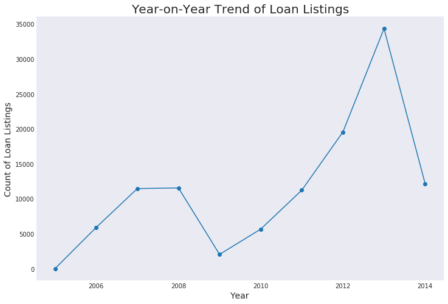

## Relative Frequency of Each Loan Status for all Loan Prosper Listed

> Overall, we see a **low default rate** amongst Prosper borrowers, as only about **17%** of total borrowers either defaulted, have their loans charged off or have their loans due within 4 months. However, due to the fact that almost 50% of loan listings were still ongoing as at the time the data was provided, it is hard to accurately assess the completion rate compared to the other loan statuses, but, generally, the completion rate observed from the data is quite impressive.

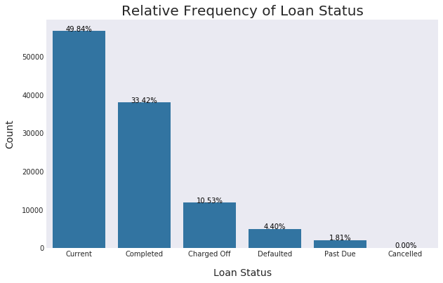

## The Relationship between Monthly Income of Borrowers and Amount of Loan Listed

> Here, we can see the distribution is concentrated around monthly income below 20,000 USD and listing amount below 35,000 USD. We see no interesting trend here. However, we do see that Prosper lists smaller loan amounts irrespective of borrowers' stated monthly income. This could be Prosper tyring to play safe (risk averse), especially since Prosper's documentation caps Prosper's listing at $40,000. The concentration in the lower income brackets could be due to factors that the data may not be able to explain. Exammining the impact of Risk ratings on Listing amount may however, shed more light.

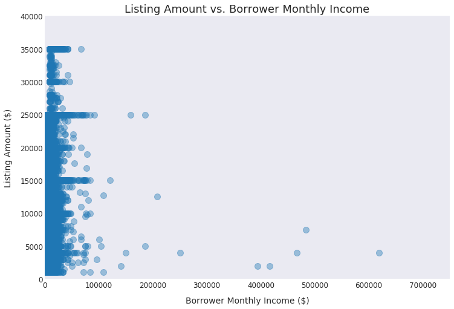

## Relationship between Prosper Risk Rating and Listed Loan Amount

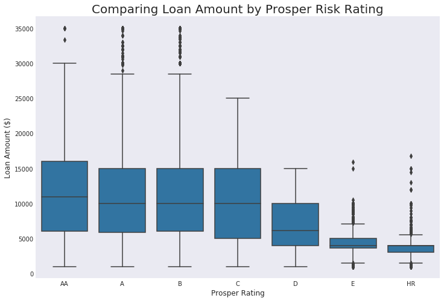

## How do different Risk ratings compare when Assessing the Relationship between Borrower APR and Estimated Loss for Borrowers?

> There is a clear pattern here. Low Risk borrowers cluster around low borrower APR and low estimated loss regions, while High Risk borrowers tend to cluster around the high borrower APR and high estimated loss regions.

> In general, a positive relationship is observed between Borrower APR and Estimated Loss and the higher the risk factor for a borrower, the higher the trade-off between APR and Estimated Loss for such borrower.

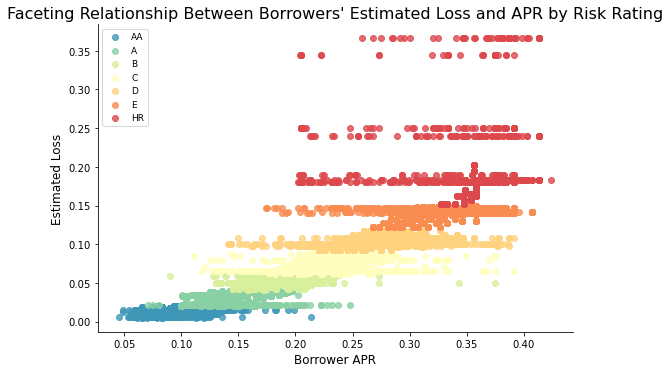

## How do the Loan Status and the Risk Rating of Borrowers Relate - with respect to Average Estimated Loss?

> This results agree with Business Domain Knowledge where it is expected that the Higher the Risk Score of a Borrower, the Higher the Business Loss expected.

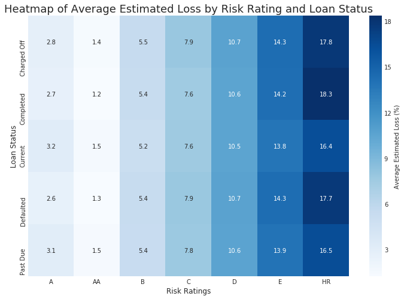